# Efficient Coding Practices

- Course: BUDT758X
- Instructor: Prof. Sean Barnes
- Student: Xukun(Frank) LIU (https://www.xukun-liu.com/)
- Topics: # Efficient Coding

Today, we will discuss some techniques for working efficiently in Python:

- Help Features
- Edit vs. Command Mode and Keyboard Shortcuts
- Syntax Highlighting, Auto Indent, Enclosure Matching
- Tab Completion
- Object Introspection
- Magic Commands
- Shell Commands
- Testing and Debugging

Most of these techniques will take time to incorporate into your work flow, but you’ll get better with use.

Other features, such as those related to command history (e.g., up/down arrows, %hist, exec, input/ouput caching, recall, etc.), are important when working within an IPython command line environment, but not so much in a Jupyter Notebook environment. We will not discuss these features in detail.

**Friendly reminders:**

- DataCamp module for Default Arguments, Variable-Length Arguments, and Scope due tonight by 11:59 p.m.

## Help Features

```python
# Overview of IPython environment
?
```

```python
# Help - Input specific function or execute with no input to enter interactive help utility (exit using quit command)
help()
```

```
Welcome to Python 3.7's help utility!

If this is your first time using Python, you should definitely check out
the tutorial on the Internet at https://docs.python.org/3.7/tutorial/.

Enter the name of any module, keyword, or topic to get help on writing
Python programs and using Python modules.  To quit this help utility and
return to the interpreter, just type "quit".

To get a list of available modules, keywords, symbols, or topics, type
"modules", "keywords", "symbols", or "topics".  Each module also comes
with a one-line summary of what it does; to list the modules whose name
or summary contain a given string such as "spam", type "modules spam".

help> pandas
Help on package pandas:

NAME
    pandas

DESCRIPTION
    pandas - a powerful data analysis and manipulation library for Python
    =====================================================================

    **pandas** is a Python package providing fast, flexible, and expressive data
    structures designed to make working with "relational" or "labeled" data both
    easy and intuitive. It aims to be the fundamental high-level building block for
    doing practical, **real world** data analysis in Python. Additionally, it has
    the broader goal of becoming **the most powerful and flexible open source data
    analysis / manipulation tool available in any language**. It is already well on
    its way toward this goal.

    Main Features
    -------------
    Here are just a few of the things that pandas does well:

      - Easy handling of missing data in floating point as well as non-floating
        point data.
      - Size mutability: columns can be inserted and deleted from DataFrame and
        higher dimensional objects
```

[output cut: 63 more lines]

```
    tslib = <module 'pandas.tslib' from '/anaconda3/lib/python3.7/site-pac...

VERSION
    0.23.4

FILE
    /anaconda3/lib/python3.7/site-packages/pandas/__init__.py


help>

You are now leaving help and returning to the Python interpreter.
If you want to ask for help on a particular object directly from the
interpreter, you can type "help(object)".  Executing "help('string')"
has the same effect as typing a particular string at the help> prompt.
```

## Edit vs. Command Mode and Keyboard Shortcuts

There are two operating modes within the Jupyter Notebook environment:

- Edit mode is indicated by a green cell border and enables editing of the cell content (i.e., code, Markdown cells)
- Command mode is indicated by a gray cell border with a blue left margine and primarily enables keyboard shortcuts

When in edit mode, press the Esc key to enter command mode (or click outside of cell). When in command mode, press the Enter key to enter Edit mode (or click inside cell). Be careful not to try to type into a cell while in command mode, or you may accidentally enter keyboard shortcuts.

Common command mode shortcuts:

- Navigation - up/down arrows
- Execution - Shift+Enter, Ctrl+Enter, Alt+Enter (these work in edit mode as well)
- Save - s
- Change cell types: y (Code), m (Markdown)
- Insert new cell: a (above), b (below)
- Edit cell: c (copy), x (cut), v (paste), dd (delete), z (undo)
- Kernel operations: ii (interrupt), 00 (restart)

```python
#Play!!
```

## Syntax Highlighting, Auto Indent, Enclosure Matching

These are features that we have already encountered, but make it easier to write and test code. These features are often the core functionality of enhanced text editors or IDEs over a basic text editor.

```python
for i, x in enumerate(range(10)):
    print('Item %d: %d' % (i,x))
```

```
Item 0: 0
Item 1: 1
Item 2: 2
Item 3: 3
Item 4: 4
Item 5: 5
Item 6: 6
Item 7: 7
Item 8: 8
Item 9: 9
```

## Tab Completion

We have encountered tab completion on a couple of examples as well, but in general, it is a very convenient feature to use for variable names, function and magic command names, object attributes and methods, and file directories and names. Use often!!

When applying tab completion to an object assigned to a variable, you must execute the code defining the variable before tab completion can be applied to the object referenced by the variable. This requirement must be similarly applied for objects associated with module imports.

```python
# Variable names
really_long_variable_name = None
```

```python
# Test tab completion
really_long_variable_name
```

```python
# Function and magic function names
%magic
```

```python
# Object attributes and methods
D = dict(zip(range(1,6), 'abcde'))
D
```

```
{1: 'a', 2: 'b', 3: 'c', 4: 'd', 5: 'e'}
```

```python
# Test tab completion
D.[tab]
```

```
  File "<ipython-input-12-cace74e57485>", line 2
    D.[tab]
      ^
SyntaxError: invalid syntax
```

```python
# Importing specific functions from modules
from numpy import
```

```
  File "<ipython-input-13-537ad229dfed>", line 2
    from numpy import
                     ^
SyntaxError: invalid syntax
```

```python
# File directories and names
'/Users/xukun.liu/'
```

```
'/Users/xukun.liu/'
```

## Object Introspection

Object introspection is essentially a task associated with learning more information about a particular object. The most common introspection tasks include:

- Inquiring about methods and attributes (similar to tab completion) - **dir** function
- Inquiring about the type of an object - **type** function
- Detailed inquiry about an object - '?'

```python
# Inquiring about methods and attributes - dir function
obj = list # example of list, can change obj to any other Python object, e.g., scalar, dictionary, function
dir(obj)
```

```
['__add__',
 '__class__',
 '__contains__',
 '__delattr__',
 '__delitem__',
 '__dir__',
 '__doc__',
 '__eq__',
 '__format__',
 '__ge__',
 '__getattribute__',
 '__getitem__',
 '__gt__',
 '__hash__',
 '__iadd__',
 '__imul__',
 '__init__',
 '__init_subclass__',
 '__iter__',
 '__le__',
 '__len__',
 '__lt__',
 '__mul__',
 '__ne__',
 '__new__',
 '__reduce__',
 '__reduce_ex__',
 '__repr__',
 '__reversed__',
 '__rmul__',
 '__setattr__',
 '__setitem__',
 '__sizeof__',
 '__str__',
 '__subclasshook__',
 'append',
 'clear',
 'copy',
 'count',
 'extend',
 'index',
 'insert',
 'pop',
 'remove',
 'reverse',
 'sort']
```

```python
# Type introspection
obj = 5 # example of a scalar, can change obj to any other Python object, e.g., scalar, dictionary, function
type(obj)
```

```
int
```

```python
# Detailed introspection - Functions
sorted?
```

## Magic Commands

Magic commands are convenience functions that are built into the IPython environment. They will not work in a standard (non-IPython) Python environment. They are intended primarily for interactive use.

Magic functions are preceded by '%' for line commands and '%%' for cell commands. Cell commands must be entered in the first line of a cell, even above a comment.

```python
%magic
```

```python
%lsmagic
```

```
Available line magics:
%alias  %alias_magic  %autoawait  %autocall  %automagic  %autosave  %bookmark  %cat  %cd  %clear  %colors  %config  %connect_info  %cp  %debug  %dhist  %dirs  %doctest_mode  %ed  %edit  %env  %gui  %hist  %history  %killbgscripts  %ldir  %less  %lf  %lk  %ll  %load  %load_ext  %loadpy  %logoff  %log…

Available cell magics:
%%!  %%HTML  %%SVG  %%bash  %%capture  %%debug  %%file  %%html  %%javascript  %%js  %%latex  %%markdown  %%perl  %%prun  %%pypy  %%python  %%python2  %%python3  %%ruby  %%script  %%sh  %%svg  %%sx  %%system  %%time  %%timeit  %%writefile

Automagic is ON, % prefix IS NOT needed for line magics.
```

```python
%page?
```

### Interacting with System Directories

```python
# Print working directory
%pwd
```

```
'/Users/xukun.liu/Google Drive (xukun.liu@rhsmith.umd.edu)/RHSmith-Sync/2-Spring-2019/1-BUDT 758X (0502)/notebook'
```

```python
# Change directory - Magic command
%cd /Users/xukun.liu/
```

```
/Users/xukun.liu
```

```python
# Change directory - os command
import os
os.chdir('/Users/seanbarnes/Dropbox/Teaching/Courses/BUDT758X/data')
%pwd
```

```
---------------------------------------------------------------------------
FileNotFoundError                         Traceback (most recent call last)
<ipython-input-23-34b58b1f1739> in <module>
      1 # Change directory - os command
      2 import os
----> 3 os.chdir('/Users/seanbarnes/Dropbox/Teaching/Courses/BUDT758X/data')
      4 get_ipython().run_line_magic('pwd', '')

FileNotFoundError: [Errno 2] No such file or directory: '/Users/seanbarnes/Dropbox/Teaching/Courses/BUDT758X/data'
```

### Namespace and Variable Storage

```python
# List variables
%who
```

```
D	 i	 obj	 os	 really_long_variable_name	 x
```

```python
# Store variable
x = 5
%store x
del x
x
```

```
Stored 'x' (int)
```

```
---------------------------------------------------------------------------
NameError                                 Traceback (most recent call last)
<ipython-input-25-bb0c0c5b39f1> in <module>
      3 get_ipython().run_line_magic('store', 'x')
      4 del x
----> 5 x

NameError: name 'x' is not defined
```

```python
# Restore variable
%store -r x
x
```

```
5
```

```python
%store?
```

### Timing and Profiling

```python
# Time line command
%time long_list = [x for x in range(10000)] # also %%time as a cell magic command, must be placed at beginning of cell
```

```
CPU times: user 432 µs, sys: 148 µs, total: 580 µs
Wall time: 584 µs
```

```python
# Timeit line command
%timeit long_list = [x for x in range(10000)] # also %%time as a cell magic command, must be placed at beginning of cell
```

```
331 µs ± 4.57 µs per loop (mean ± std. dev. of 7 runs, 1000 loops each)
```

```python
# Profile command
%prun [x for x in map(lambda num: num ** 2, long_list)]
```

### matplotlib and pylab

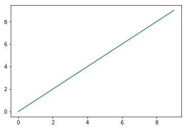

```python
# matplotlib - Enables inline plotting, does not import matplotlib module
%matplotlib inline
import matplotlib.pyplot as plt
plt.plot(range(10)); # suppress matplotlib output with ';'
```

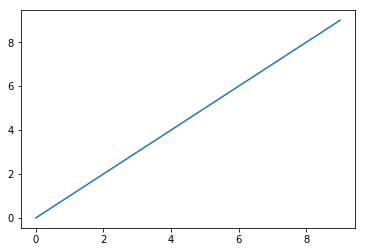

```python
# pylab - Imports numpy as np, matplotlib.pyplot as plt and enables inline plotting
%pylab inline
plt.plot(range(10)); # suppress matplotlib output with ';'
```

## Shell Commands

Shell (Unix) commands can be executed from within the IPython environment, taking advantage of the extensive operating system functionality that exists. This is one example of how easily Python can interactive with other programming languages.

```python
# Basic shell commands
!pwd
```

```
/Users/xukun.liu
```

```python
# Outputting variables to shell
var = 'Test'
!echo $var
```

```
Test
```

```python
!ls
```

```
Applications
Applications (Parallels)
Books
Desktop
Documents
Downloads
Google Drive
Google Drive (xukun.liu@rhsmith.umd.edu)
Library
Movies
Music
Parallels
Pictures
Public
Virtual Machines.localized
github
nltk_data
venv
```

```python
# Shell command - Capture shell output
!!ls
```

```
['Applications',
 'Applications (Parallels)',
 'Books',
 'Desktop',
 'Documents',
 'Downloads',
 'Google Drive',
 'Google Drive (xukun.liu@rhsmith.umd.edu)',
 'Library',
 'Movies',
 'Music',
 'Parallels',
 'Pictures',
 'Public',
 'Virtual Machines.localized',
 'github',
 'nltk_data',
 'venv']
```

```python
# Assign previous results to variable
files = _ # special variable name for most recent output
files
```

```
['Applications',
 'Applications (Parallels)',
 'Books',
 'Desktop',
 'Documents',
 'Downloads',
 'Google Drive',
 'Google Drive (xukun.liu@rhsmith.umd.edu)',
 'Library',
 'Movies',
 'Music',
 'Parallels',
 'Pictures',
 'Public',
 'Virtual Machines.localized',
 'github',
 'nltk_data',
 'venv']
```

## Testing and Debugging

Testing and debugging form a critical part of the code development process. Testing involves making sure that your code performs as you intend over the full range of use cases. Debugging is the process of correcting errors in your code. The most common errors are:

- Syntax errors
- Exceptions
- Logical errors

Syntax errors occur when the parser for the code detects an error that prevents the code from executing, and occur most often in the following cases:

- Missing colons for code blocks (e.g., def, if, for, while, class)
- Indentation errors for code blocks (e.g., def, if, for, while, class)
- Missing parenthesis for function calls (unless %autocall is enabled)
- Mismatched enclosurse (e.g., parentheses, brackets, braces, quotes)
- Missing commas when defining sequence or collection
- Using = (assignment) instead of == (conditional)

Exceptions occur when the syntax is technically correct, but an error occurs during the execution of the code. Common exceptions include:

- Name errors (e.g., misspelling/case, undefined, not imported, out of scope)
- Index or key errors (e.g., index out-of-range, non-integer index, key error)
- Type errors (i.e., applying operation or function to wrong type of object)
- Value errors (i.e., apply operation or function to right type but inappropriate value)
- Zero division errors
- Import and module not found errors
- File not found errors

A complete list of built-in exceptions can be found at:

https://docs.python.org/3/library/exceptions.html#bltin-exceptions (See 5.2 Concrete Exceptions)

When an exception occurs, Python will report the *(stack) traceback*, which provides the hierarchical structure of how the error occurred. The traceback can help you figure out how to correct the problem. Learning how to recognize the different types of exceptions and how to navigate the traceback are important skills for debugging your code.

In addition to errors that cause exceptions, there are many types of logical errors that are more subtle to detect. Generally, these errors encompass cases when the code executes to completion, but the objective was not satisfied.

We will discuss three approaches for investigating, correcting, and managing errors:

- **print** statements
- Interactive debugging - %debug magic command
- Exception Handling

```python
# Syntax error - Missing colon
if True
    print(True)
```

```
  File "<ipython-input-38-629dbf1c54f7>", line 2
    if True
           ^
SyntaxError: invalid syntax
```

```python
# Exception - Type error
5 + '6'
```

```
---------------------------------------------------------------------------
TypeError                                 Traceback (most recent call last)
<ipython-input-39-df3748cb2830> in <module>
      1 # Exception - Type error
----> 2 5 + '6'

TypeError: unsupported operand type(s) for +: 'int' and 'str'
```

```python
# Logical error - Flatten list of lists
L1 = [[1,2,3],[4,5],[6,7,8,9,10]]
L2 = []
for L in L1:
    L2.append(L)
L2
```

```
[[1, 2, 3], [4, 5], [6, 7, 8, 9, 10]]
```

```python
# Logical error - Flatten list of lists
L1 = [[1,2,3],[4,5],[6,7,8,9,10]]
L2 = []
for L in L1:
    for element in L:
        L2.append(element)
L2
```

```
[1, 2, 3, 4, 5, 6, 7, 8, 9, 10]
```

### **print** statements

The use of **print** statements is the simplest approach to debugging your code. Essentially, the strategy is to insert **print** statements at strategic locations within your code so as to find where the error occurs.

```python
# Logical error - Flatten list of lists
L1 = [[1,2,3],[4,5],[6,7,8,9,10]]
L2 = []
for L in L1:
    print(L)
    L2.append(L)
L2
```

```
[1, 2, 3]
[4, 5]
[6, 7, 8, 9, 10]
```

```
[[1, 2, 3], [4, 5], [6, 7, 8, 9, 10]]
```

```python
# Function example
def add(x=0, y=0):
    print(x, y, x+y)
    return x + y
```

```python
add()
add(5)
add(y=5)
add(y=10, x=5)
```

```
0 0 0
5 0 5
0 5 5
5 10 15
```

```
15
```

### %debug magic command

The %debug magic command invokes a command line debugger that you can use interactively to find the error that raised the exception. When you execute the %debug magic command, the debugger will revisit the most recent exception.

The most common commands from within the debugger environment are:

- **u** to move up a level in the code hierarchy
- **d** to move down a level in the code hierarchy
- **h** for help
- **q** to quit the debugger

You can toggle automatic execution of the debuger with the %pdb magic command.

```python
add(5,'6')
```

```
---------------------------------------------------------------------------
TypeError                                 Traceback (most recent call last)
<ipython-input-45-f0af8483638e> in <module>
----> 1 add(5,'6')

<ipython-input-43-771413bdd2cc> in add(x, y)
      1 # Function example
      2 def add(x=0, y=0):
----> 3     print(x, y, x+y)
      4     return x + y

TypeError: unsupported operand type(s) for +: 'int' and 'str'
```

```python
%debug
```

```
> <ipython-input-43-771413bdd2cc>(3)add()
      1 # Function example
      2 def add(x=0, y=0):
----> 3     print(x, y, x+y)
      4     return x + y

ipdb> c
```

### Exception Handling

The primary mechanism for handling exceptions is the **try** statement. Essentially, the idea is to try a particular statement, and if that statement raises an exception, try another statement, and so on. There can be multiple exception statements.

```python
def add(obj1, obj2):
    try:
        return obj1 + obj2
    except TypeError:
        print('Objects must be of the same type for the \'+\' operator to be valid')
    except:
        print('Something else is wrong')
```

```python
add([5],'5')
```

```
Objects must be of the same type for the '+' operator to be valid
```

## Next Time: NumPy